# SPRM_Project

Matt Hirschi

November 27, 2018

## Question

Does the distance and type of shot effect how many baskets they make?

Null: freethrow = threepointer Alternative: freethrow not equal to threepointer

Null: p1=p2=p3=p4=p5=p6=p7=p8 Alternative: At least one is different

Null: underhand = regular Alternative: not equal to eachother

I assigned each shooter a number between 1-8 and then used a random number generator to choose the order they shot and which shot they used as well what distance they shot from.

The factors were the distance they shot from, the person, and the type of shot they shot. The response was how many shots they made.

## Numerical Descriptive Statistics

```r
favstats(dat$made ~ dat$x_u_feff_distance)
```

```
##   dat$x_u_feff_distance min   Q1 median   Q3 max mean       sd n missing
## 1             freethrow   2 4.75    5.5 7.25   9 5.75 2.251983 8       0
## 2            threepoint   4 4.75    7.0 8.25  10 6.75 2.314550 8       0
```

```r
favstats(dat$made ~ dat$person)
```

```
##   dat$person min   Q1 median   Q3 max mean        sd n missing
## 1          1   7 7.25    7.5 7.75   8  7.5 0.7071068 2       0
## 2          2   5 6.00    7.0 8.00   9  7.0 2.8284271 2       0
## 3          3   4 4.50    5.0 5.50   6  5.0 1.4142136 2       0
## 4          4   2 2.75    3.5 4.25   5  3.5 2.1213203 2       0
## 5          5   4 4.50    5.0 5.50   6  5.0 1.4142136 2       0
## 6          6   8 8.50    9.0 9.50  10  9.0 1.4142136 2       0
## 7          7   4 5.25    6.5 7.75   9  6.5 3.5355339 2       0
## 8          8   5 5.75    6.5 7.25   8  6.5 2.1213203 2       0
```

```r
favstats(dat$made ~ dat$type)
```

```
##    dat$type min   Q1 median  Q3 max  mean       sd n missing
## 1   regular   2 4.75    6.0 7.5  10 6.125 2.587746 8       0
## 2 underhand   4 4.75    6.5 8.0   9 6.375 2.065879 8       0
```

## Descriptive Graphics

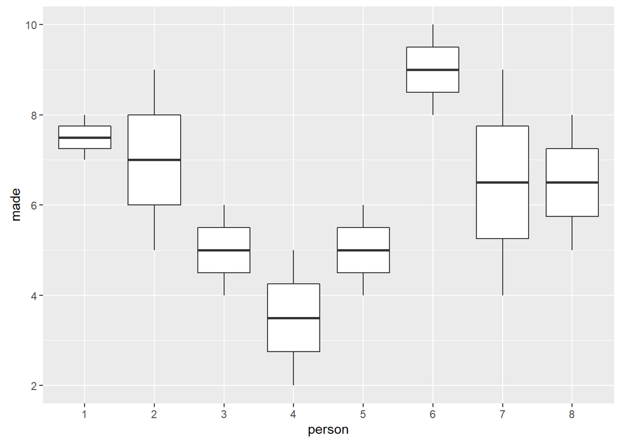

```r
dat %>%
  ggplot(aes(x = person, y = made))+
  geom_boxplot()
```

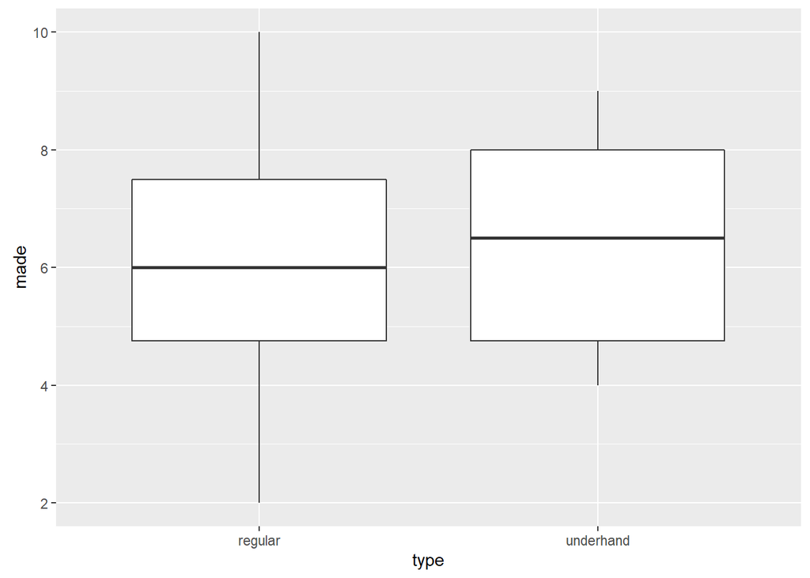

```r
dat %>%
  ggplot(aes(x = type, y = made))+
  geom_boxplot()
```

## Inferential Statistics

```r
model <- aov(made ~ x_u_feff_distance + person + type + x_u_feff_distance:person, data = dat)

model1 <- aov(made ~ x_u_feff_distance + Error(person) + type + x_u_feff_distance:person,
             data = dat)

summary(model1)
```

```
##
## Error: person
##                          Df Sum Sq Mean Sq
## x_u_feff_distance         1      4   4.000
## x_u_feff_distance:person  6     37   6.167
##
## Error: Within
##           Df Sum Sq Mean Sq F value Pr(>F)
## type       1   0.25   0.250   0.049  0.831
## Residuals  7  35.75   5.107
```

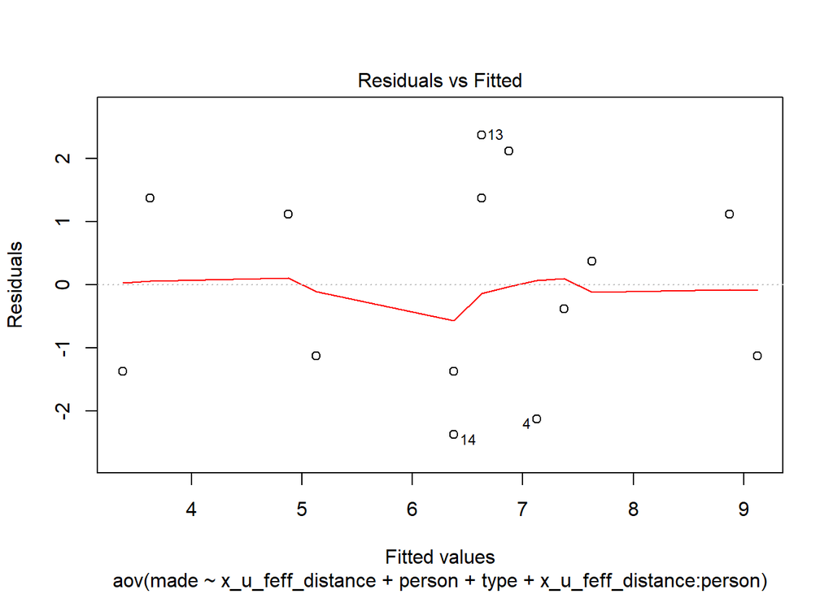

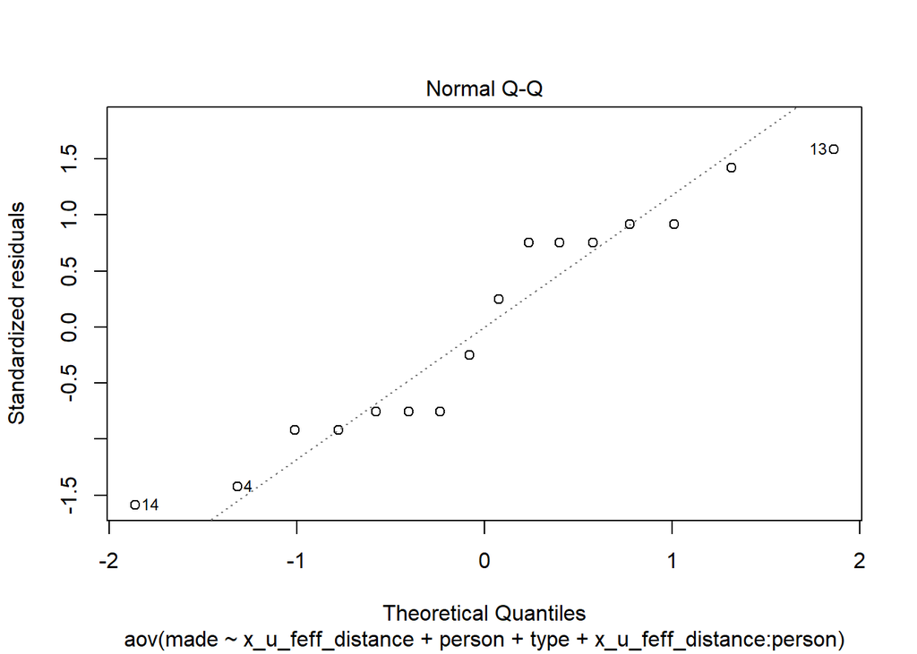

```r
plot(model, which = 1:2)
```

## Conclusion

I think I got the results I did because everyone was quite good at basketball and were on their game this day. I would have found random people to do this experiment instead of people I knew and their skill level.